# Heart Failure Prediction

Lola Gómez Jemes

El dataset elegido para este proyecto ha sido Heart Failure Prediction, disponible en Kaggle (link: https://www.kaggle.com/andrewmvd/heart-failure-clinical-data).

Las enfermedades cardiovasculares (ECV) son la primera causa de muerte en el mundo, y se calcula que se cobran 17,9 millones de vidas cada año.

En este documento se recoge una primera toma de contacto con los datos, en el que se van a estudiar algunos de los atributos del dataset y su influencia o no en la supervivencia del paciente.

Antes de comenzar a trabajar con los datos, vamos a cargar dos librerías: * Dplyr: es uno de los paquetes principales de tidyverse. Se trata de un conjunto de funciones diseñadas para permitir la manipulación de marcos * Ggplot2: s un paquete de visualización de datos.

```r
library(dplyr)
library(ggplot2)
```

A continuación, procedemos a cargar los datos. Además, vamos a utilizar una serie de funciones para comenzar a conocer los datos.

```r
data <- read.csv('./data/heart_failure.csv')
str(data)
```

```
'data.frame':   299 obs. of  13 variables:
 $ age                     : int  75 55 65 50 65 90 75 60 65 80 ...
 $ anaemia                 : int  0 0 0 1 1 1 1 1 0 1 ...
 $ creatinine_phosphokinase: int  582 7861 146 111 160 47 246 315 157 123 ...
 $ diabetes                : int  0 0 0 0 1 0 0 1 0 0 ...
 $ ejection_fraction       : int  20 38 20 20 20 40 15 60 65 35 ...
 $ high_blood_pressure     : int  1 0 0 0 0 1 0 0 0 1 ...
 $ platelets               : num  265000 263358 162000 210000 327000 ...
 $ serum_creatinine        : num  1.9 1.1 1.3 1.9 2.7 2.1 1.2 1.1 1.5 9.4 ...
 $ serum_sodium            : int  130 136 129 137 116 132 137 131 138 133 ...
 $ sex                     : int  1 1 1 1 0 1 1 1 0 1 ...
 $ smoking                 : int  0 0 1 0 0 1 0 1 0 1 ...
 $ time                    : int  4 6 7 7 8 8 10 10 10 10 ...
 $ death                   : int  1 1 1 1 1 1 1 1 1 1 ...
```

```r
dim(data)
```

```
[1] 299  13
```

```r
colnames(data)
```

```
 [1] "age"                      "anaemia"                  "creatinine_phosphokinase"
 [4] "diabetes"                 "ejection_fraction"        "high_blood_pressure"
 [7] "platelets"                "serum_creatinine"         "serum_sodium"
[10] "sex"                      "smoking"                  "time"
[13] "death"
```

Como se ha podido observar, el data set contiene 299 instancias y 13 atributos. Estos atributos son: edad, anemia (1: sí, 0:no), nivel de creatina, diabetes (1: sí, 0:no), fracción de eyección, presión sanguínea (1: alta, 0:no está alta), nivel de plaquetas , nivel de creatina sérica, sodio sérico, sexo, fumador (1: sí, 0:no), tiempo (hace refencia al tiempo que se ha estado haciendo seguimiento al paciente), y muerte (1:muerto, 0:vivo).

Vamos a echar un vistazo a los datos. Para ello, vamos a mostras las 5 primeras instancias del data frame:

```r
head(data)
```

|  | age | anaemia | creatinine_phosphokinase | diabetes | ejection_fraction | high_blood_pressure | platelets | serum_creatinine | serum_sodium | sex | smoking | time | death |
| --- | --- | --- | --- | --- | --- | --- | --- | --- | --- | --- | --- | --- | --- |
| 1 | 75 | 0 | 582 | 0 | 20 | 1 | 265000 | 1.9 | 130 | 1 | 0 | 4 | 1 |
| 2 | 55 | 0 | 7861 | 0 | 38 | 0 | 263358 | 1.1 | 136 | 1 | 0 | 6 | 1 |
| 3 | 65 | 0 | 146 | 0 | 20 | 0 | 162000 | 1.3 | 129 | 1 | 1 | 7 | 1 |
| 4 | 50 | 1 | 111 | 0 | 20 | 0 | 210000 | 1.9 | 137 | 1 | 0 | 7 | 1 |
| 5 | 65 | 1 | 160 | 1 | 20 | 0 | 327000 | 2.7 | 116 | 0 | 0 | 8 | 1 |
| 6 | 90 | 1 | 47 | 0 | 40 | 1 | 204000 | 2.1 | 132 | 1 | 1 | 8 | 1 |

A continuación, vamos a calcular cuántos pacientes han fallecido:

```r
death<- data %>%
  group_by(data$death) %>%
  count()



colnames(death)<-c('Fallecido','Total')
death
```

| Fallecido | Total |
| --- | --- |
| 0 | 203 |
| 1 | 96 |

Ahora, vamos a visualizar la mortalidad según el sexo:

```r
death_by_gender <- data %>%
  filter(death==1) %>%
  group_by(sex)%>%
  count()


 death_by_gender <- death_by_gender%>%
   mutate(porcentaje_muertos= round(n*100/sum(death_by_gender$n),2))

death_by_gender$sex[death_by_gender$sex==1]<-'hombre'
death_by_gender$sex[death_by_gender$sex==0]<-'mujer'

death_by_gender
```

| sex | n | porcentaje_muertos |
| --- | --- | --- |
| mujer | 34 | 35.42 |
| hombre | 62 | 64.58 |

A simple vista, parece que la mortalidad es más alta en hombres que en mujeres, pero al calcular el porcentaje de muertos en cada sexo nos encontramos frente a esto:

```r
porc_mujer<- data %>%
  filter(sex==0) %>%
  group_by(death)%>%
  count()

porc_mujer<- porc_mujer%>%
  mutate(porcentaje_muertos= round(n*100/sum(porc_mujer$n),2))


colnames(porc_mujer)<- c('Fallecida', 'Total', 'Porcentaje' )
porc_mujer
```

| Fallecida | Total | Porcentaje |
| --- | --- | --- |
| 0 | 71 | 67.62 |
| 1 | 34 | 32.38 |

```r
porc_hombre<- data %>%
  filter(sex==1) %>%
  group_by(death)%>%
  count()

porc_hombre<-porc_hombre%>%
  mutate(porcentaje_muertos= round(n*100/sum(porc_hombre$n),2))


colnames(porc_hombre)<- c('Fallecido', 'Total', 'Porcentaje' )
porc_hombre
```

| Fallecido | Total | Porcentaje |
| --- | --- | --- |
| 0 | 132 | 68.04 |
| 1 | 62 | 31.96 |

```r
NA
```

El 31,96% de las hombres totales han fallecido, frente al 32,37% de las mujeres.

A continuación, vamos a estudiar la edad. Vamos a crear dos gráficas, en las que se muestre el número de personas vivas y muertas según la edad.

```r
min(data$age)
```

```
[1] 40
```

```r
max(data$age)
```

```
[1] 95
```

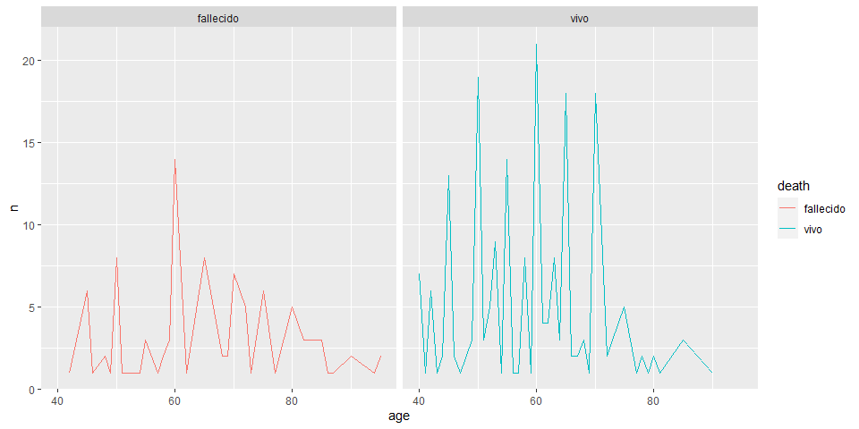

```r
edad_death<- data%>%
  group_by(age, death) %>%
  arrange(data$age)%>%
  count()

edad_death$death[edad_death$death==0]<-'vivo'
edad_death$death[edad_death$death==1]<-'fallecido'


ggplot(data= edad_death, mapping = aes(x=age, y=n, color=death))+
  geom_line()+
  facet_wrap(~death)
```

```r
NA
NA
```

Vemos que tenemos un pico de personas fallecidas en torno a los 60 años.

Vamos a ver la edad media de cada grupo. Además, vamos a enfrentar este valor a la mediana.

```r
media_supervivientes <- data %>%
  filter(death==0)%>%
  summarise(mean(age), median(age))

media_supervivientes
```

| mean(age) | median(age) |
| --- | --- |
| 58.75862 | 60 |

```r
media_muertos <- data %>%
  filter(death==1)%>%
  summarise(mean(age), median(age))

media_muertos
```

| mean(age) | median(age) |
| --- | --- |
| 65.20833 | 65 |

La edad media de muerte se encuentra en torno a los 65 años, frente a la de supervivencia de 59 años.

Veamos ahora si, a simple vista, el factor fumar afecta a la supervivencia de los pacientes.

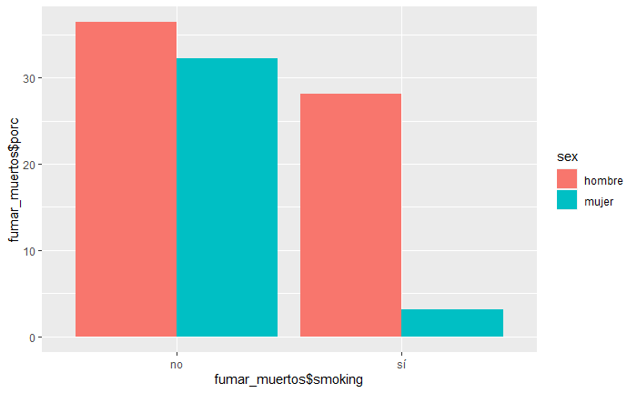

```r
fumar_muertos <- data %>%
  filter(death==1)%>%
  group_by(smoking, sex) %>%
  count()


fumar_muertos<- fumar_muertos %>%
  mutate(porc=n*100/sum(fumar_muertos$n)) %>%
  arrange(smoking)

fumar_muertos$sex[fumar_muertos$sex==0]<-'mujer'
fumar_muertos$sex[fumar_muertos$sex==1]<-'hombre'
fumar_muertos$smoking[fumar_muertos$smoking==0]<-'no'
fumar_muertos$smoking[fumar_muertos$smoking==1]<-'sí'


ggplot(data= fumar_muertos, aes(x=fumar_muertos$smoking, y=fumar_muertos$porc, fill=sex))+
  geom_bar(stat="identity", position="dodge")
```

```r
fumadora <- data%>%
  filter(sex==0, smoking==1)%>%
  count()

fumadora
```

| n |
| --- |
| 4 |

En esta gráfica se muestran el porcentaje de personas fallecidas que eran o no fumadoras, por sexo. Como podemos observar, el hecho de fumar no ha provocado una diferencia significativa, exectuando en las mujeres atendidas. Esto se debe a que tan solo 4 mujeres del total eran fumadoras.

Veamos ahora la presión arterial alta:

```r
hiper_tension <-data %>%
  filter(data$high_blood_pressure==1) %>%
  group_by(death)%>%
  count()

hiper_tension
```

| death | n |
| --- | --- |
| 0 | 66 |
| 1 | 39 |

```r
cpk_mujeres<- data%>%
  filter(data$sex==0 , data$creatinine_phosphokinase>294) %>%
  group_by(death)%>%
  count()

cpk_mujeres
```

| death | n |
| --- | --- |
| 0 | 35 |
| 1 | 13 |

```r
cpk_hombres<- data%>%
  filter(data$sex==1 , data$creatinine_phosphokinase>211) %>%
  group_by(death)%>%
  count()
cpk_hombres
```

| death | n |
| --- | --- |
| 0 | 72 |
| 1 | 37 |

```r
porc_muert_muj_cpk<- cpk_mujeres$n[cpk_mujeres$death==1]*100/death_by_gender$porcentaje_muertos[death_by_gender$sex=='mujer']

porc_muert_hombre_cpk<- cpk_hombres$n[cpk_hombres$death==1]*100/death_by_gender$porcentaje_muertos[death_by_gender$sex=='hombre']

porc_muert_hombre_cpk
```

```
[1] 57.29328
```

```r
porc_muert_muj_cpk
```

```
[1] 36.70243
```